# EFA Project Group E

# EFA

### Extracing Eigenvalues

#### DVs

The eigenvalues for the dependent variables are 2.783, 0.729, 0.355, and 0.133.

- Kaiser’s Criterion: 1
- Jollife’s : 2
- Inflection Point : 1

Although Kaiser’s criterion and the skree plot indicate intrinsic dimensionality of 1, Jolliffe’s criterion indicates 2, and domain knowledge tells us that two factors would be more interpretable, as it would separate deaths due to pollution from deaths due to other causes. We will go with intrinsic dimensionality of 2 for the dependent variables.

```r
dv_d <- data_mat_no_outliers[,c("dth_c", "dth_d", "dth_k", "dth_p")]
dv_r <- cor(dv_d)
dv_l <- eigen(dv_r)$values
round(dv_l, digits = 3)
```

```
## [1] 2.783 0.729 0.355 0.133
```

```r
sum(dv_l > 1.0)
```

```
## [1] 1
```

```r
sum(dv_l > 0.7)
```

```
## [1] 2
```

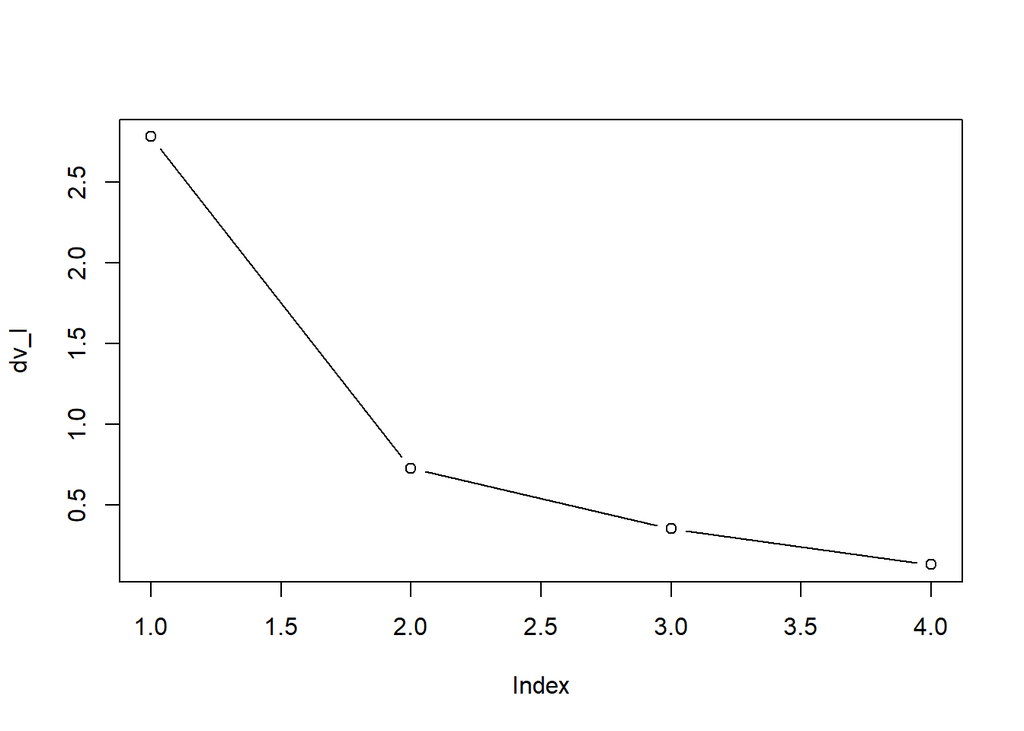

```r
plot(dv_l, type = "b")
```

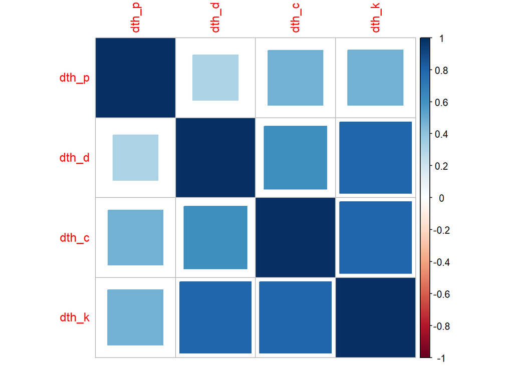

```r
corrplot(dv_r, method = "square", order = "hclust")
```

#### IVs

The eigenvalues for the independent variables are 2.619, 1.165, 0.519, 0.399, 0.298.

- Kaiser’s Criterion : 2
- Jolliffe’s Criterion: 2
- Inflection Point : 2

As every criterion indicates intrinsic dimensionality of 2, we will go with that.

```r
iv_d <- data_mat_no_outliers[, 1:5]
iv_r <- cor(iv_d, use = "pairwise.complete.obs")
iv_l <- eigen(iv_r)$values
round(iv_l, digits = 3)
```

```
## [1] 2.619 1.165 0.519 0.399 0.298
```

```r
sum(iv_l > 1.0)
```

```
## [1] 2
```

```r
sum(iv_l > 0.7)
```

```
## [1] 2
```

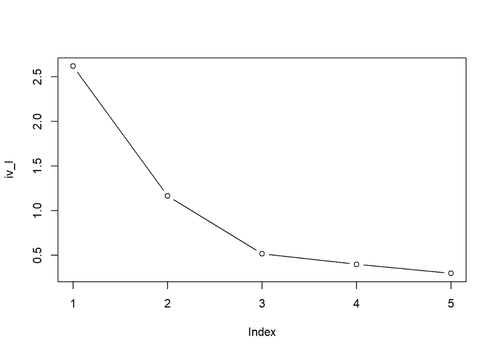

```r
plot(iv_l, type = "b")
```

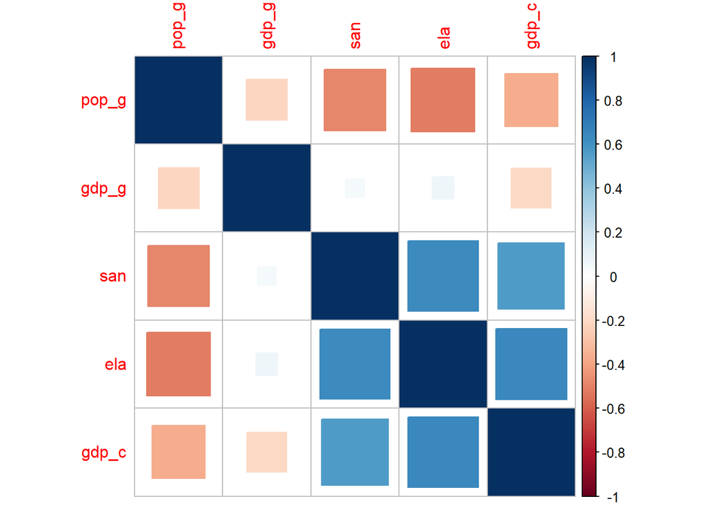

```r
corrplot(iv_r, method = "square", order = "hclust")
```

### Optimally Rotated Loading Matrices

#### DVs

The orthogonally rotated loading matrix has quite a bit of complexity, with dth_c and dth_k loading above 0.3 on both factors. The oblique rotation improves this significantly, with all loadings being pure, and the factor correlation is above 0.3, indicating oblique rotation is warranted.

```r
dv_arot_orth <- pca(
  r = dv_r,
  nfactors = 2,
  rotate = "varimax"
)
dv_arot_orth$loadings
```

```
##
## Loadings:
##       RC1   RC2
## dth_c 0.796 0.382
## dth_d 0.916
## dth_k 0.907 0.302
## dth_p 0.214 0.964
##
##                  RC1   RC2
## SS loadings    2.341 1.171
## Proportion Var 0.585 0.293
## Cumulative Var 0.585 0.878
```

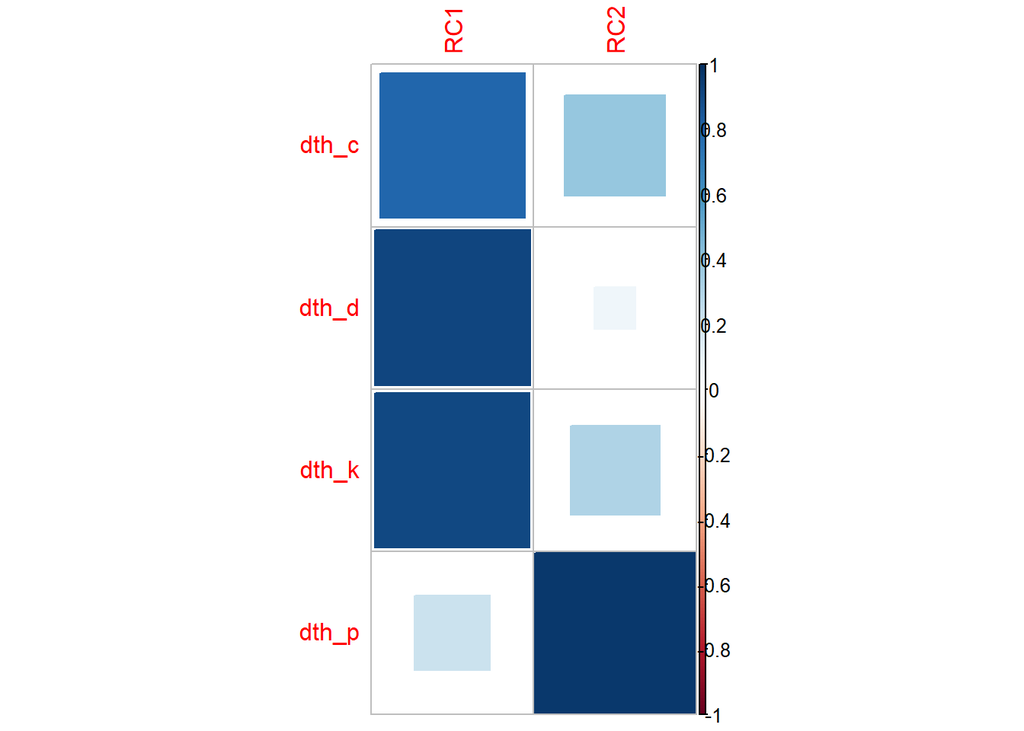

```r
corrplot(dv_arot_orth$loadings, method = "square")
```

```r
dv_arot_obli <- pca(
  r = dv_r,
  nfactors = 2,
  rotate = "oblimin"
)
dv_arot_obli$Phi
```

```
##           PC1       PC2
## PC1 1.0000000 0.4150681
## PC2 0.4150681 1.0000000
```

```r
dv_arot_obli$loadings
```

```
##
## Loadings:
##       PC1    PC2
## dth_c  0.775  0.210
## dth_d  0.973 -0.159
## dth_k  0.912
## dth_p         0.978
##
##                  PC1   PC2
## SS loadings    2.379 1.036
## Proportion Var 0.595 0.259
## Cumulative Var 0.595 0.854
```

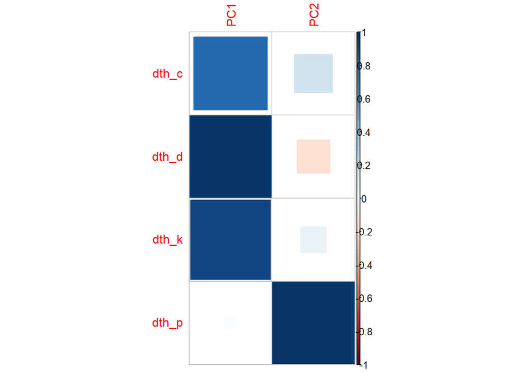

```r
corrplot(dv_arot_obli$loadings, method = "square")
```

#### IVs

Both the orthogonally and obliquely rotated loading matrices have complexity, with gdp_c and pop_g having two loadings above 0.3 in both. Oblique rotation does not improve this, and the factor correlations are very small at only 0.01, indicating oblique rotation is not necessary.

```r
iv_arot_orth <- pca(
  r = iv_r,
  nfactors = 2,
  rotate = "varimax"
)
iv_arot_orth$loadings
```

```
##
## Loadings:
##       RC1    RC2
## san    0.836
## ela    0.876
## gdp_c  0.817 -0.333
## gdp_g         0.943
## pop_g -0.692 -0.408
##
##                  RC1   RC2
## SS loadings    2.614 1.171
## Proportion Var 0.523 0.234
## Cumulative Var 0.523 0.757
```

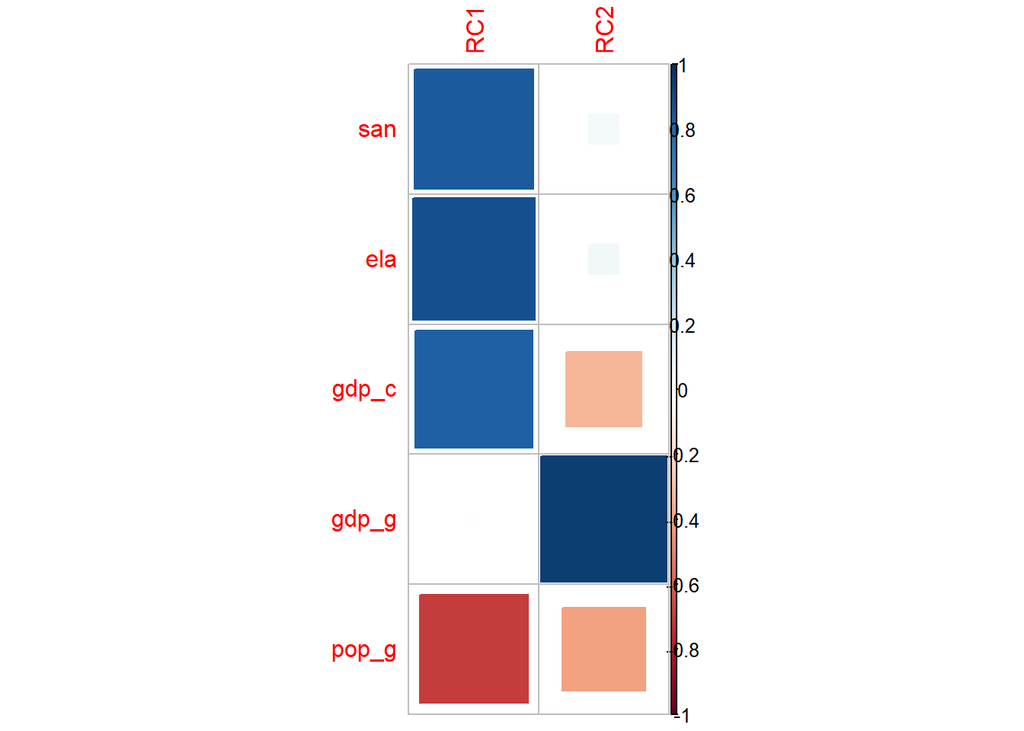

```r
corrplot(iv_arot_orth$loadings, method = "square")
```

```r
iv_arot_obli <- pca(
  r = iv_r,
  nfactors = 2,
  rotate = "oblimin"
)
iv_arot_obli$Phi
```

```
##            PC1        PC2
## PC1 1.00000000 0.01357389
## PC2 0.01357389 1.00000000
```

```r
iv_arot_obli$loadings
```

```
##
## Loadings:
##       PC1    PC2
## san    0.836
## ela    0.876
## gdp_c  0.820 -0.338
## gdp_g         0.943
## pop_g -0.689 -0.403
##
##                  PC1   PC2
## SS loadings    2.613 1.170
## Proportion Var 0.523 0.234
## Cumulative Var 0.523 0.757
```

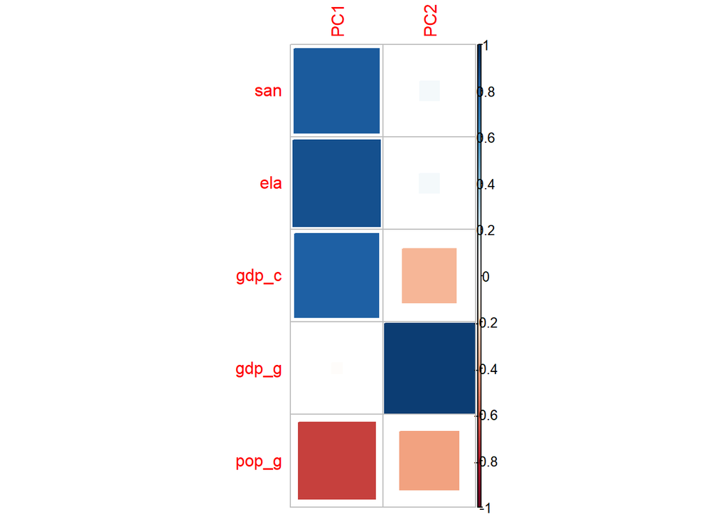

```r
corrplot(iv_arot_obli$loadings, method = "square")
```

### Variance Retained

#### DVs

Examining the output of pca(), we find that he cumulative variance retained is 0.88 for the two factor model, which is above the guideline of 0.7. For individual dimensions, dth_c has the highest proportion of variance lost, at 0.22, below the guideline of 0.30. For the residual correlations matrix, the only original dimension pair with a proportion of covariability lost above the +-0.10 guideline is dth_c and dth_d, with a residual of -0.139. Complexity is not a significant issue, with a mean Hofmann’s Complexity Index of 1.1, and dth_c having the highest individual complexity at 1.15.

```r
dv_arot_obli
```

```
## Principal Components Analysis
## Call: principal(r = r, nfactors = nfactors, residuals = residuals,
##     rotate = rotate, n.obs = n.obs, covar = covar, scores = scores,
##     missing = missing, impute = impute, oblique.scores = oblique.scores,
##     method = method, use = use, cor = cor, correct = 0.5, weight = NULL,
##     n.rotations = n.rotations)
## Standardized loadings (pattern matrix) based upon correlation matrix
##        PC1   PC2   h2    u2 com
## dth_c 0.77  0.21 0.78 0.220 1.1
## dth_d 0.97 -0.16 0.84 0.157 1.1
## dth_k 0.91  0.10 0.91 0.086 1.0
## dth_p 0.02  0.98 0.98 0.025 1.0
##
##                        PC1  PC2
## SS loadings           2.43 1.08
## Proportion Var        0.61 0.27
## Cumulative Var        0.61 0.88
## Proportion Explained  0.69 0.31
## Cumulative Proportion 0.69 1.00
##
##  With component correlations of
##      PC1  PC2
## PC1 1.00 0.42
## PC2 0.42 1.00
##
## Mean item complexity =  1.1
## Test of the hypothesis that 2 components are sufficient.
##
## The root mean square of the residuals (RMSR) is  0.05
##
## Fit based upon off diagonal values = 0.99
```

```r
round(dv_arot_obli$residual, digits = 3)
```

```
##        dth_c  dth_d  dth_k  dth_p
## dth_c  0.220 -0.139 -0.038 -0.066
## dth_d -0.139  0.157 -0.051  0.060
## dth_k -0.038 -0.051  0.086 -0.009
## dth_p -0.066  0.060 -0.009  0.025
```

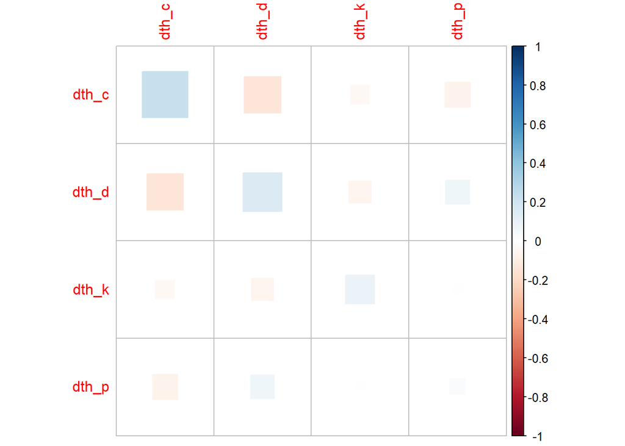

```r
corrplot(dv_arot_obli$residual, method = "square")
```

#### IVs

The cumulative variance retained for the independent variables is lower, at only 0.76. Additionally, pop_g’s proportion of variance lost is above the 30% guideline at 35.5%, and san’s is extremely close at 29.8% The residual matrix indicated a large amount of covariability lost, with 5 pairs above 0.10 (san x gdp_c, san x pop_g, ela x pop_g, gdp_g x gdp_c, and gdp_g x pop_g). For the independent variables, complexity somewhat concerning, with a mean Hofmann’s complexity of 1.2, and gdp_c (1.33) and pop_g (1.61) both having complexity above the 1.3 guideline.

```r
iv_arot_obli
```

```
## Principal Components Analysis
## Call: principal(r = r, nfactors = nfactors, residuals = residuals,
##     rotate = rotate, n.obs = n.obs, covar = covar, scores = scores,
##     missing = missing, impute = impute, oblique.scores = oblique.scores,
##     method = method, use = use, cor = cor, correct = 0.5, weight = NULL,
##     n.rotations = n.rotations)
## Standardized loadings (pattern matrix) based upon correlation matrix
##         PC1   PC2   h2   u2 com
## san    0.84  0.04 0.70 0.30 1.0
## ela    0.88  0.05 0.77 0.23 1.0
## gdp_c  0.82 -0.34 0.78 0.22 1.3
## gdp_g -0.01  0.94 0.89 0.11 1.0
## pop_g -0.69 -0.40 0.64 0.36 1.6
##
##                        PC1  PC2
## SS loadings           2.61 1.17
## Proportion Var        0.52 0.23
## Cumulative Var        0.52 0.76
## Proportion Explained  0.69 0.31
## Cumulative Proportion 0.69 1.00
##
##  With component correlations of
##      PC1  PC2
## PC1 1.00 0.01
## PC2 0.01 1.00
##
## Mean item complexity =  1.2
## Test of the hypothesis that 2 components are sufficient.
##
## The root mean square of the residuals (RMSR) is  0.07
##
## Fit based upon off diagonal values = 0.97
```

```r
round(iv_arot_obli$residual, digits = 3)
```

```
##          san    ela  gdp_c gdp_g pop_g
## san    0.298 -0.098 -0.102 0.004 0.115
## ela   -0.098  0.230 -0.054 0.020 0.108
## gdp_c -0.102 -0.054  0.221 0.116 0.069
## gdp_g  0.004  0.020  0.116 0.111 0.166
## pop_g  0.115  0.108  0.069 0.166 0.355
```

```r
abs(iv_arot_obli$residual) > 0.1
```

```
##         san   ela gdp_c gdp_g pop_g
## san    TRUE FALSE  TRUE FALSE  TRUE
## ela   FALSE  TRUE FALSE FALSE  TRUE
## gdp_c  TRUE FALSE  TRUE  TRUE FALSE
## gdp_g FALSE FALSE  TRUE  TRUE  TRUE
## pop_g  TRUE  TRUE FALSE  TRUE  TRUE
```

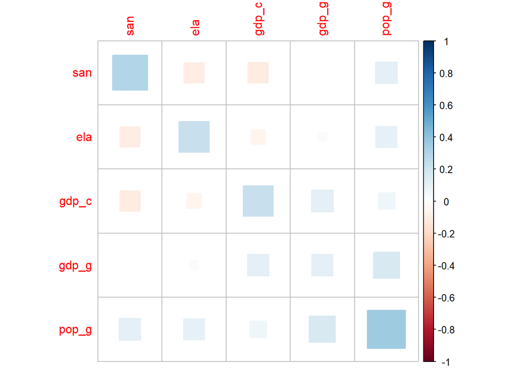

```r
corrplot(iv_arot_obli$residual, method = "square")
```

### Final Loading Matrices

#### A<sub>resp</sub>

Our final choice for our A<sub>resp</sub> matrix is the obliquely rotated matrix.

```r
A_resp <- matrix(
  data = dv_arot_obli$loadings,
  ncol = 2,
  dimnames = dimnames(dv_arot_obli$loadings)
)
A_resp
```

```
##              PC1         PC2
## dth_c 0.77488522  0.20997222
## dth_d 0.97262265 -0.15888865
## dth_k 0.91206937  0.09587996
## dth_p 0.02155687  0.97835562
```

#### A<sub>pred</sub>

Our final choice for our A<sub>pred</sub> matrix is our orthogonally rotated matrix.

```r
A_pred <- matrix(
  data = iv_arot_orth$loadings,
  ncol = 2,
  dimnames = dimnames(iv_arot_orth$loadings)
)
A_pred
```

```
##               RC1         RC2
## san    0.83645673  0.04998470
## ela    0.87603941  0.05165147
## gdp_c  0.81747090 -0.33254447
## gdp_g -0.00732381  0.94258879
## pop_g -0.69156631 -0.40789686
```